# Twitter US Airline Sentiment

## Context

Twitter possesses 330 million monthly active users, which allows businesses to reach a broad population and connect with customers without intermediaries. On the other hand, there’s so much information that it’s difficult for brands to quickly detect negative social mentions that could harm their business.

That's why sentiment analysis/classification, which involves monitoring emotions in conversations on social media platforms, has become a key strategy in social media marketing.

Listening to how customers feel about the product/service on Twitter allows companies to understand their audience, keep on top of what’s being said about their brand and their competitors, and discover new trends in the industry.

## Data Description

- A sentiment analysis job about the problems of each major U.S. airline.
- Twitter data was scraped from February of 2015 and contributors were asked to first classify positive, negative, and neutral tweets, followed by categorizing negative reasons (such as "late flight" or "rude service").

## Dataset

The dataset has the following columns:

- tweet_id
- airline_sentiment
- airline_sentiment_confidence
- negativereason
- negativereason_confidence
- airline
- airline_sentiment_gold
- name
- negativereason_gold
- retweet_count
- text
- tweet_coord
- tweet_created
- tweet_location
- user_timezone

## Objective:

- To classify the sentiment of tweets into the positive, neutral & negative.

# Learning Outcomes:

- Text based EDA
- Basic understanding of text pre-processing.
- What to do after text pre-processing:
  - Bag of words
  - Tf-idf
- Build the classification model.
- Tune & Evaluate the Model performance.
- Plot the important features after training the model.

# Importing Libraries

```python
# Modules for Preprocessing data

import re, string, unicodedata                          # Import Regex, string and unicodedata.
!pip install contractions
import contractions                                     # Import contractions library.
from bs4 import BeautifulSoup                           # Import BeautifulSoup.

import numpy as np                                      # Import numpy.
import pandas as pd                                     # Import pandas.
pd.set_option('display.max_colwidth', None) # Display full dataframe information (Non-turncated Text column.)

# Modules from NLTK

import nltk                                             # Import Natural Language Tool-Kit.

nltk.download('stopwords')    #download stopwords
nltk.download('punkt')
nltk.download('wordnet')
nltk.download('omw-1.4')

from nltk.corpus import stopwords                   #Stopwords corpus
from nltk.stem import PorterStemmer                 # Stemmer
from nltk.tokenize import word_tokenize, sent_tokenize
from nltk.stem.wordnet import WordNetLemmatizer         # Import Lemmatizer.

# Modules from sklearn library

from sklearn.feature_extraction.text import CountVectorizer          #For Bag of words
from sklearn.feature_extraction.text import TfidfVectorizer          #For TF-IDF
from sklearn.model_selection import KFold , StratifiedKFold, cross_val_score
from sklearn.metrics import accuracy_score
from sklearn.ensemble import RandomForestClassifier       # Import Random forest Classifier
from sklearn import metrics
from sklearn.metrics import classification_report, confusion_matrix         # Import Classification report and confusion_matrix
from sklearn.model_selection import train_test_split      # Split data into training and testing set

# Unsupervised model import
!pip install vaderSentiment
from vaderSentiment.vaderSentiment import SentimentIntensityAnalyzer    # vader sentiment analysis
!pip install textblob
from textblob import TextBlob  # textblob sentiment analysis

# Modules for graphical representaion

import matplotlib.pyplot as plt
import seaborn as sns
from wordcloud import WordCloud,STOPWORDS

# Supress warning

import warnings
warnings.filterwarnings("ignore")
```

## Mounting Drive

```python
from google.colab import drive
drive.mount('/content/drive/')
```

## Reading Dataset

```python
# loading data
airline_data = pd.read_csv("/content/drive/My Drive/Colab Notebooks/NLP/Tweets.csv")
```

```python
# Checking Shape of the data
airline_data.shape
```

```
(14640, 15)
```

- There are 14640 rows and 15 columns

```python
# Display five random rows of the data
airline_data.sample(5)
```

|  | tweet_id | airline_sentiment | airline_sentiment_confidence | negativereason | negativereason_confidence | airline | airline_sentiment_gold | name | negativereason_gold | retweet_count | text | tweet_coord | tweet_created | tweet_location | user_timezone |
| --- | --- | --- | --- | --- | --- | --- | --- | --- | --- | --- | --- | --- | --- | --- | --- |
| 4794 | 569731104070115329 | positive | 1.0000 | NaN | NaN | Southwest | NaN | JasmineDT | NaN | 1 | @SouthwestAir you're my early frontrunner for best airline! #oscars2016 | NaN | 2015-02-22 21:30:54 -0800 | Washington D.C. | Eastern Time (US & Canada) |
| 10480 | 569263373092823040 | negative | 1.0000 | Cancelled Flight | 1.0000 | US Airways | NaN | ElizabethFrayer | NaN | 0 | @USAirways how is it that my flt to EWR was Cancelled Flightled yet flts to NYC from USAirways are still flying? | NaN | 2015-02-21 14:32:19 -0800 | NaN | NaN |
| 8067 | 568818669024907264 | negative | 1.0000 | Late Flight | 0.6770 | Delta | NaN | The_Radifier | NaN | 0 | @JetBlue what is going on with your BDL to DCA flights yesterday and today?! Why is every single one getting delayed? | NaN | 2015-02-20 09:05:13 -0800 | Arlington, VA | Atlantic Time (Canada) |
| 8880 | 567775864679456768 | neutral | 1.0000 | NaN | NaN | Delta | NaN | rnlewisjr | NaN | 0 | @JetBlue do they have to depart from Washington, D.C.?? | NaN | 2015-02-17 12:01:29 -0800 | iPhone: 60.495510,-151.064590 | Alaska |
| 8292 | 568526521910079488 | negative | 0.6625 | Customer Service Issue | 0.3394 | Delta | NaN | beantoon | NaN | 0 | @JetBlue I can probably find some of them. Are the ticket #s on there? | NaN | 2015-02-19 13:44:20 -0800 | Plymouth, MA | NaN |

```python
# Unique values on the sentiment column
airline_data.airline_sentiment.unique()
```

```
array(['neutral', 'positive', 'negative'], dtype=object)
```

```python
# Missing Values
(airline_data.isnull().sum()/len(airline_data)).sort_values(ascending=False)
```

```
negativereason_gold             0.997814
airline_sentiment_gold          0.997268
tweet_coord                     0.930396
negativereason                  0.373087
user_timezone                   0.329235
tweet_location                  0.323292
negativereason_confidence       0.281284
tweet_id                        0.000000
airline_sentiment               0.000000
airline_sentiment_confidence    0.000000
airline                         0.000000
name                            0.000000
retweet_count                   0.000000
text                            0.000000
tweet_created                   0.000000
dtype: float64
```

```python
#Checking the data types of the columns for the dataset
airline_data.info()
```

```
<class 'pandas.core.frame.DataFrame'>
RangeIndex: 14640 entries, 0 to 14639
Data columns (total 15 columns):
 #   Column                        Non-Null Count  Dtype
---  ------                        --------------  -----
 0   tweet_id                      14640 non-null  int64
 1   airline_sentiment             14640 non-null  object
 2   airline_sentiment_confidence  14640 non-null  float64
 3   negativereason                9178 non-null   object
 4   negativereason_confidence     10522 non-null  float64
 5   airline                       14640 non-null  object
 6   airline_sentiment_gold        40 non-null     object
 7   name                          14640 non-null  object
 8   negativereason_gold           32 non-null     object
 9   retweet_count                 14640 non-null  int64
 10  text                          14640 non-null  object
 11  tweet_coord                   1019 non-null   object
 12  tweet_created                 14640 non-null  object
 13  tweet_location                9907 non-null   object
 14  user_timezone                 9820 non-null   object
dtypes: float64(2), int64(2), object(11)
memory usage: 1.7+ MB
```

- The airline_sentiment is categorized as 'neutral', 'positive', 'negative'.
- There are a more than 90% data missing on airline_sentiment_gold, negativereason_gold and tweet_coord columns.
- airline_sentiment_confidence, negativereason_confidence and retweet_count are numeric columns, rest all are categorical columns.

# Exploratory Data Analysis

## Tweets per airline

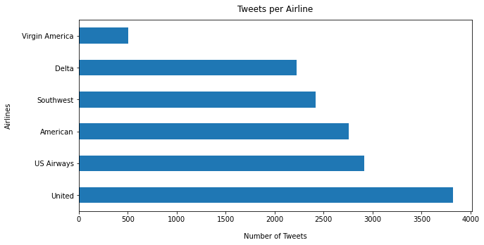

```python
# The number of tweets per airline
airline_data.airline.value_counts().plot(kind = 'barh', figsize=(10, 5))
plt.ylabel("Airlines", labelpad=14)
plt.xlabel("Number of Tweets", labelpad=14)
plt.title("Tweets per Airline", y=1.02);
```

- The dataset consists of 6 major airlines, viz, 'Virgin America', 'United', 'Southwest', 'Delta', 'US Airways', and 'American'.
- 'United' has maximum tweets.
- 'Virgin America' has the lowest number of tweets.
- All other airline has tweets ranging around 2500 to 3000.

## Distribution of Sentiments

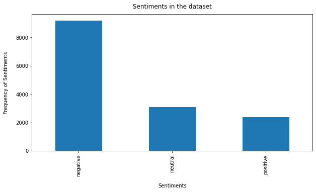

```python
# Counts of airline sentiments in the data
airline_data.airline_sentiment.value_counts().plot(kind = 'bar', figsize=(10, 5))
plt.ylabel("Frequency of Sentiments", labelpad=14)
plt.xlabel("Sentiments", labelpad=14)
plt.title("Sentiments in the dataset", y=1.02);
```

```
airline_sentiment  negative  neutral  positive    All
airline
All                    9178     3099      2363  14640
Southwest              1186      664       570   2420
Delta                   955      723       544   2222
United                 2633      697       492   3822
American               1960      463       336   2759
US Airways             2263      381       269   2913
Virgin America          181      171       152    504
------------------------------------------------------------------------------------------------------------------------
```

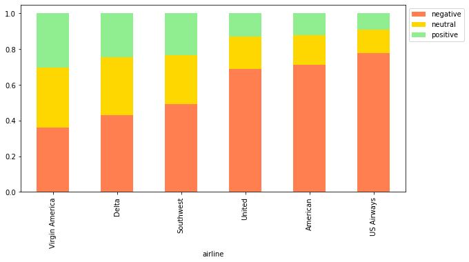

```python
# Distribution of proportion of sentiments by various airlines in the data
sorter = airline_data.airline_sentiment.value_counts().index[-1]
tab1 = pd.crosstab(airline_data.airline, airline_data.airline_sentiment, margins=True).sort_values(
	by=sorter, ascending=False
)
print(tab1)
print("-" * 120)

tab = pd.crosstab(airline_data.airline, airline_data.airline_sentiment, normalize="index").sort_values(
	by=sorter, ascending=False
)
tab.plot(kind="bar", stacked=True, color=['coral', 'gold','lightgreen'], figsize=(10, 5))
plt.legend(
	loc="lower left",
	frameon=False,
)
plt.legend(loc="upper left", bbox_to_anchor=(1, 1))
plt.show()
```

```
airline            American  Delta  Southwest  US Airways  United  \
airline_sentiment
All                    2759   2222       2420        2913    3822
negative               1960    955       1186        2263    2633
neutral                 463    723        664         381     697
positive                336    544        570         269     492

airline            Virgin America    All
airline_sentiment
All                           504  14640
negative                      181   9178
neutral                       171   3099
positive                      152   2363
------------------------------------------------------------------------------------------------------------------------
```

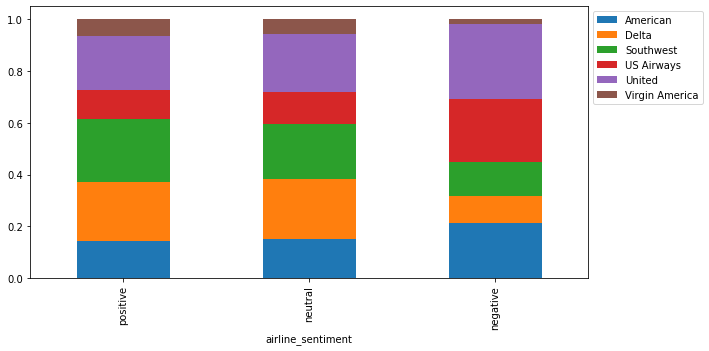

```python
# Airline has has maximum positive sentiments
sorter = airline_data.airline.value_counts().index[-1]
tab1 = pd.crosstab(airline_data.airline_sentiment, airline_data.airline, margins=True).sort_values(
	by=sorter, ascending=False
)
print(tab1)
print("-" * 120)

tab = pd.crosstab(airline_data.airline_sentiment, airline_data.airline, normalize="index").sort_values(
	by=sorter, ascending=False
)
tab.plot(kind="bar", stacked=True, figsize=(10, 5))
plt.legend(
	loc="lower left",
	frameon=False,
)
plt.legend(loc="upper left", bbox_to_anchor=(1, 1))
plt.show()
```

```
count    14640.000000
mean         0.900169
std          0.162830
min          0.335000
25%          0.692300
50%          1.000000
75%          1.000000
max          1.000000
Name: airline_sentiment_confidence, dtype: float64
------------------------------------------------------------------------------------------------------------------------
```

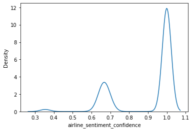

```python
# Distribution of airline_sentiment_confidence data in the dataset
print(airline_data.airline_sentiment_confidence.describe())
print("-" * 120)
sns.kdeplot(data=airline_data, x="airline_sentiment_confidence")
```

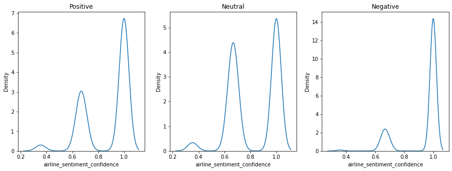

```python
# Distribution of airline_sentiment_confidence score by airline_sentiment
temp_df = airline_data[['airline_sentiment', 'airline_sentiment_confidence']]
positive = temp_df.loc[temp_df['airline_sentiment'] == 'positive']['airline_sentiment_confidence']
negative = temp_df.loc[temp_df['airline_sentiment'] == 'negative']['airline_sentiment_confidence']
neutral = temp_df.loc[temp_df['airline_sentiment'] == 'neutral']['airline_sentiment_confidence']

fig, axs= plt.subplots(1, 3, figsize=(15, 5))
axs[0].set_title("Positive")
sns.kdeplot(data=airline_data, x=positive, ax = axs[0])
axs[1].set_title("Neutral")
sns.kdeplot(data=airline_data, x=neutral, ax = axs[1])
axs[2].set_title("Negative")
sns.kdeplot(data=airline_data, x=negative, ax = axs[2])
```

## Distribution of Negative Reasons

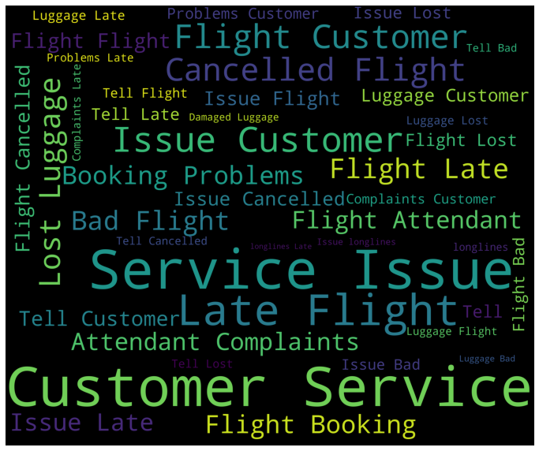

```python
#creating word cloud for negative reviews
negative_reviews=airline_data[airline_data['airline_sentiment']=='negative']
words = ' '.join(negative_reviews['negativereason'])
cleaned_word = " ".join([word for word in words.split()])

wordcloud = WordCloud(stopwords=STOPWORDS,
                      background_color='black',
                      width=3000,
                      height=2500
                     ).generate(cleaned_word)

plt.figure(1,figsize=(12, 12))
plt.imshow(wordcloud)
plt.axis('off')
plt.show()
```

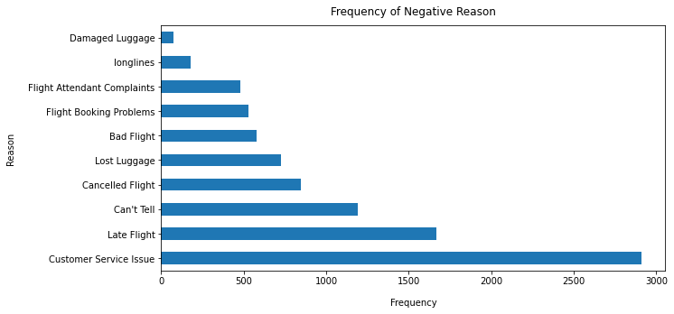

```python
# The frequency of negative reasons
airline_data.negativereason.value_counts().plot(kind = 'barh', figsize=(10, 5))
plt.ylabel("Reason", labelpad=14)
plt.xlabel("Frequency", labelpad=14)
plt.title("Frequency of Negative Reason", y=1.02);
```

```python
# Create a function to remove the @title from the text on negative review data
def cleaning_text(record):
  my_text = record['text']
  text = re.sub(r'@[A-Za-z]*', '', my_text).strip()
  return text
```

```python
# Apply the function and create a new column
negative_reviews['clean_text'] = negative_reviews.apply(lambda record: cleaning_text(record), axis = 1)
```

```python
# Validate the head
negative_reviews.head()
```

|  | tweet_id | airline_sentiment | airline_sentiment_confidence | negativereason | negativereason_confidence | airline | airline_sentiment_gold | name | negativereason_gold | retweet_count | text | tweet_coord | tweet_created | tweet_location | user_timezone | clean_text |
| --- | --- | --- | --- | --- | --- | --- | --- | --- | --- | --- | --- | --- | --- | --- | --- | --- |
| 3 | 570301031407624196 | negative | 1.0000 | Bad Flight | 0.7033 | Virgin America | NaN | jnardino | NaN | 0 | @VirginAmerica it's really aggressive to blast obnoxious "entertainment" in your guests' faces &amp; they have little recourse | NaN | 2015-02-24 11:15:36 -0800 | NaN | Pacific Time (US & Canada) | it's really aggressive to blast obnoxious "entertainment" in your guests' faces &amp; they have little recourse |
| 4 | 570300817074462722 | negative | 1.0000 | Can't Tell | 1.0000 | Virgin America | NaN | jnardino | NaN | 0 | @VirginAmerica and it's a really big bad thing about it | NaN | 2015-02-24 11:14:45 -0800 | NaN | Pacific Time (US & Canada) | and it's a really big bad thing about it |
| 5 | 570300767074181121 | negative | 1.0000 | Can't Tell | 0.6842 | Virgin America | NaN | jnardino | NaN | 0 | @VirginAmerica seriously would pay $30 a flight for seats that didn't have this playing.\nit's really the only bad thing about flying VA | NaN | 2015-02-24 11:14:33 -0800 | NaN | Pacific Time (US & Canada) | seriously would pay $30 a flight for seats that didn't have this playing.\nit's really the only bad thing about flying VA |
| 15 | 570282469121007616 | negative | 0.6842 | Late Flight | 0.3684 | Virgin America | NaN | smartwatermelon | NaN | 0 | @VirginAmerica SFO-PDX schedule is still MIA. | NaN | 2015-02-24 10:01:50 -0800 | palo alto, ca | Pacific Time (US & Canada) | SFO-PDX schedule is still MIA. |
| 17 | 570276917301137409 | negative | 1.0000 | Bad Flight | 1.0000 | Virgin America | NaN | heatherovieda | NaN | 0 | @VirginAmerica I flew from NYC to SFO last week and couldn't fully sit in my seat due to two large gentleman on either side of me. HELP! | NaN | 2015-02-24 09:39:46 -0800 | this place called NYC | Eastern Time (US & Canada) | I flew from NYC to SFO last week and couldn't fully sit in my seat due to two large gentleman on either side of me. HELP! |

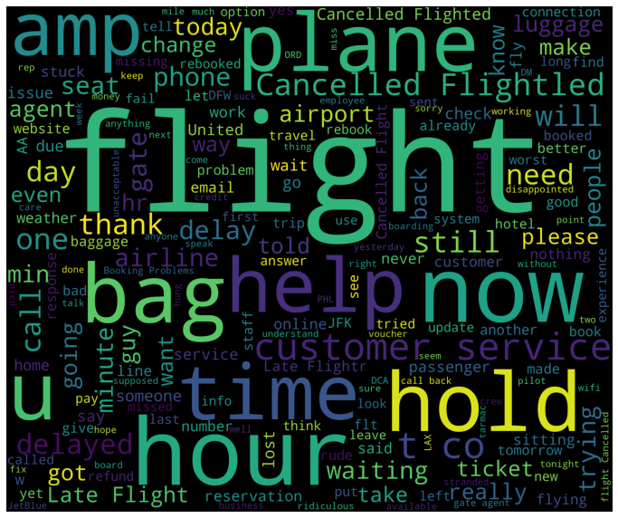

```python
#creating word cloud for negative tweets
words = ' '.join(negative_reviews['clean_text'])
cleaned_word = " ".join([word for word in words.split()])

wordcloud = WordCloud(stopwords=STOPWORDS,
                      background_color='black',
                      width=3000,
                      height=2500
                     ).generate(cleaned_word)

plt.figure(1,figsize=(12, 12))
plt.imshow(wordcloud)
plt.axis('off')
plt.show()
```

- Various issues are highlighted on the Negative Reasons, few of them are "Customer Service", "Service Issue", "Late Flight", "Cancelled Flight" etc..
- THe word cloud on the negative tweets highlighted many words like "Cancelled flight", "Bag", "Delay", "Time", "Customer Service" etc..

## Distribution words on Positive tweets

```python
# Create a filtered dataframe for positive tweets
positive_reviews=airline_data[airline_data['airline_sentiment']=='positive']
```

```python
# Apply the cleaning_text function and create a new column
positive_reviews['clean_text'] = positive_reviews.apply(lambda record: cleaning_text(record), axis = 1)
positive_reviews.sample(5)
```

|  | tweet_id | airline_sentiment | airline_sentiment_confidence | negativereason | negativereason_confidence | airline | airline_sentiment_gold | name | negativereason_gold | retweet_count | text | tweet_coord | tweet_created | tweet_location | user_timezone | clean_text |
| --- | --- | --- | --- | --- | --- | --- | --- | --- | --- | --- | --- | --- | --- | --- | --- | --- |
| 11666 | 567840122454052864 | positive | 0.6854 | NaN | NaN | US Airways | NaN | wickenstein | NaN | 0 | @USAirways HA! You're fun. | NaN | 2015-02-17 16:16:49 -0800 | Charleston, SC | Eastern Time (US & Canada) | HA! You're fun. |
| 11976 | 570279118438182913 | positive | 1.0000 | NaN | NaN | American | NaN | kdtate | NaN | 0 | @AmericanAir great, thanks! | NaN | 2015-02-24 09:48:31 -0800 | NaN | NaN | great, thanks! |
| 331 | 568605449659895808 | positive | 0.6482 | NaN | NaN | Virgin America | NaN | SuuperG | NaN | 0 | @VirginAmerica Thanks! | NaN | 2015-02-19 18:57:58 -0800 | Wandering So-Cal-ian | Pacific Time (US & Canada) | Thanks! |
| 8304 | 568502766747971585 | positive | 1.0000 | NaN | NaN | Delta | NaN | bwsf93 | NaN | 0 | @JetBlue thanks to Julian at login for getting me onto an earlier flight back to DCA | NaN | 2015-02-19 12:09:56 -0800 | NOVA | America/New_York | thanks to Julian at login for getting me onto an earlier flight back to DCA |
| 4378 | 570280800244994048 | positive | 1.0000 | NaN | NaN | Southwest | NaN | NinjaEpisode | NaN | 0 | @SouthwestAir I agree! RT @9NEWS: One airline is the fly-away favorite at DIA #9NEWSBusiness http://t.co/o3WlaInImY | NaN | 2015-02-24 09:55:12 -0800 | Denver, CO | NaN | I agree! RT 9NEWS: One airline is the fly-away favorite at DIA #9NEWSBusiness http://t.co/o3WlaInImY |

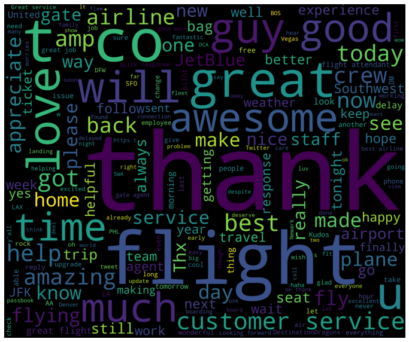

```python
#creating word cloud for negative tweets
words = ' '.join(positive_reviews['clean_text'])
cleaned_word = " ".join([word for word in words.split()])

wordcloud = WordCloud(stopwords=STOPWORDS,
                      background_color='black',
                      width=3000,
                      height=2500
                     ).generate(cleaned_word)

plt.figure(1,figsize=(12, 12))
plt.imshow(wordcloud)
plt.axis('off')
plt.show()
```

- The word cloud on the positive tweets highlighted words like "Thank", "Love", "Awesome", "Good" etc..

## Overall Summary from EDA

- Virgin America has lowest number of tweets in the dataset, but it is having positive sentiments amongst it's consumers.
- Southwest seems to be having the most number of positive tweets and is amongst the airline having less negative sentiments, as per the dataset.
- Most of the comments in the dataset shows negative sentiment.
- The most common negative sentiment words are "Customer Service", "Cancelled Flight" etc...
- The most common positive sentiment words are "Thank", "Love", "Awesome" etc...

# Data Preparation for modeling

- We shall create a new dataframe with three columns.
- Since our objective is to do Sentiment analysis on the tweets, we shall retain 'text' column of the dataset along with airline_sentiment and negativereason column.

```python
# Create a new dataframe for the sentiment analysis
sentiment_data = airline_data[['airline_sentiment', 'negativereason', 'text']].copy()
sentiment_data.sample(3)
```

|  | airline_sentiment | negativereason | text |
| --- | --- | --- | --- |
| 12886 | neutral | NaN | @AmericanAir New marketing song? https://t.co/F2LFULCbQ7 let us know what you think? http://t.co/NBZkhiZF3V |
| 9840 | negative | longlines | @USAirways stuck at the gate in Charlotte, NC waiting for "release papers" and a fix for a broken computer system. |
| 14105 | negative | Late Flight | @AmericanAir Nice AA employee making skillful excuses about Late Flightness due to catering snafu... http://t.co/YPVPVdlTYs |

### Data Pre-processing

```python
# Remove the @name from the tweets
sentiment_data['text'] = sentiment_data.apply(lambda record: cleaning_text(record), axis = 1)
```

```python
# Validate the dataframe
sentiment_data.sample(3)
```

|  | airline_sentiment | negativereason | text |
| --- | --- | --- | --- |
| 6617 | neutral | NaN | I absolutely will. Where can I send it? |
| 1151 | negative | longlines | gate C 24 IAD. U released passengers to board w/others deplaning .50 peopleOn bridge while next flight board http://t.co/HfoF33iyhi |
| 1642 | neutral | NaN | I am UA elite Gold and have a UA Chase pres. plus credit card. How many EQM's do I need to get Platinum Elite! |

### Text Pre-processing

We have used **NLTK library to tokenize words , remove stopwords and lemmatize the remaining words**.

```python
# Strip HTML in text column
def strip_html(text):
    soup = BeautifulSoup(text, "html.parser")
    return soup.get_text()

sentiment_data['text'] = sentiment_data['text'].apply(lambda x: strip_html(x))
sentiment_data['negativereason'] = sentiment_data['negativereason'].apply(lambda x: strip_html(x) if pd.notnull(x) else x)

sentiment_data.sample(3)
```

|  | airline_sentiment | negativereason | text |
| --- | --- | --- | --- |
| 4795 | neutral | NaN | , kudos to your rep "Patricia" at gate B11 this Sunday morning at #Chicago #Midway #MDW,… http://t.co/MmCWkqp2gy |
| 2320 | negative | Can't Tell | no bag tagging, led to many people backing up the aisle to front with bags |
| 13664 | negative | Can't Tell | has to be the worst airline in the world #yousuck #horrible #Oscars2015 |

```python
# Remove contracttion from text column
def replace_contractions(text):
    """Replace contractions in string of text"""
    return contractions.fix(text)
sentiment_data['text'] = sentiment_data['text'].apply(lambda x: replace_contractions(x))
sentiment_data['negativereason'] = sentiment_data['negativereason'].apply(lambda x: replace_contractions(x) if pd.notnull(x) else x)
sentiment_data.sample(3)
```

|  | airline_sentiment | negativereason | text |
| --- | --- | --- | --- |
| 14296 | negative | Flight Attendant Complaints | flight 1081 from IAD to LAX sat for more than 3hrs because ground crew could not drive in snow #badmgmt #AmericanAirlines |
| 13074 | negative | Flight Booking Problems | No. Had to Cancelled Flight my trip. Instead of a $25 future trip voucher, a $25 drink coupon would have been better! #WakingInMemphis |
| 11528 | negative | Late Flight | what is policy on changing flight to different dates once your flight has been delayed? |

```python
# Remove hashtags
def remove_hashtags(record):
  my_text = record['text']
  text = re.sub(r'#\w*', '', my_txt).strip()
  return text
  sentiment_data['text'] = sentiment_data['text'].apply(lambda x: remove_hashtags(x))
```

```python
# Remove Numbers
def remove_numbers(text):
  text = re.sub(r'\d+', '', text)
  return text

sentiment_data['text'] = sentiment_data['text'].apply(lambda x: remove_numbers(x))
sentiment_data.sample(3)
```

|  | airline_sentiment | negativereason | text |
| --- | --- | --- | --- |
| 10160 | negative | Customer Service Issue | no one is coming to line. On hold for hours. Can you help here if I provide conf code? |
| 4199 | negative | Lost Luggage | Hi JH, my experience with United has been entirely disgusting but yes, I would like assistance in getting compensated for my bag. |
| 10227 | negative | Late Flight | working for me. Tight cx so they are delaying our flight. Twice. In secs http://t.co/GUywQH |

```python
# Tokenize the words in the text column
sentiment_data['text']  = sentiment_data.apply(lambda row: nltk.word_tokenize(row['text']), axis=1) # Tokenization of data
sentiment_data.sample(3)
```

|  | airline_sentiment | negativereason | text |
| --- | --- | --- | --- |
| 8466 | positive | NaN | [Amazingly, Awesome, customer, service, from, your, reservation, agents, tonight, ., Helping, correct, a, mistake, ., I, so, love, this, airline, ., :, )] |
| 2612 | positive | NaN | [DM, sent, ., Thanks, .] |
| 3030 | negative | Customer Service Issue | [I, am, sure, you, will, offer, me, nothing, for, the, inconvenience, you, have, put, me, through, TWICE, this, month, ., Tweets, do, not, cut, it] |

```python
# Describe the Stopword list to be removed from the data
stopwords = stopwords.words('english')

customlist = ['not', "couldn't", 'didn', "didn't", 'doesn', "doesn't", 'hadn', "hadn't", 'hasn',
        "hasn't", 'haven', "haven't", 'isn', "isn't", 'ma', 'mightn', "mightn't", 'mustn',
        "mustn't", 'needn', "needn't", 'shan', "shan't", 'shouldn', "shouldn't", 'wasn',
        "wasn't", 'weren', "weren't", 'won', "won't", 'wouldn', "wouldn't"]

# Set custom stop-word's list as not, couldn't etc. words matter in Sentiment, so not removing them from original data.

stopwords = list(set(stopwords) - set(customlist))
```

```python
# Cleaning rest of the data
lemmatizer = WordNetLemmatizer()

def remove_non_ascii(words):
    """Remove non-ASCII characters from list of tokenized words"""
    new_words = []
    for word in words:
        new_word = unicodedata.normalize('NFKD', word).encode('ascii', 'ignore').decode('utf-8', 'ignore')
        new_words.append(new_word)
    return new_words

def to_lowercase(words):
    """Convert all characters to lowercase from list of tokenized words"""
    new_words = []
    for word in words:
        new_word = word.lower()
        new_words.append(new_word)
    return new_words

def remove_punctuation(words):
    """Remove punctuation from list of tokenized words"""
    new_words = []
    for word in words:
        new_word = re.sub(r'[^\w\s]', '', word)
        if new_word != '':
            new_words.append(new_word)
    return new_words

def remove_stopwords(words):
    """Remove stop words from list of tokenized words"""
    new_words = []
    for word in words:
        if word not in stopwords:
            new_words.append(word)
    return new_words

def lemmatize_list(words):
    new_words = []
    for word in words:
      new_words.append(lemmatizer.lemmatize(word, pos='v'))
    return new_words

def normalize(words):
    words = remove_non_ascii(words)
    words = to_lowercase(words)
    words = remove_punctuation(words)
    words = remove_stopwords(words)
    words = lemmatize_list(words)
    return ' '.join(words)

# We shall apply normalize process only on 'text' column as negativereason column has all standard list of data as seen in EDA
sentiment_data['text'] = sentiment_data.apply(lambda row: normalize(row['text']), axis=1)
sentiment_data.sample(5)
```

|  | airline_sentiment | negativereason | text |
| --- | --- | --- | --- |
| 12462 | neutral | NaN | lol great answer agents check passengers quickly possible appreciate patience |
| 13924 | negative | Customer Service Issue | write detail letter experience today never experience awful cs ever |
| 13730 | positive | NaN | today yyz bite bag issue clear beautifully thank check |
| 9980 | negative | Lost Luggage | say luggage hold almost hrs hang x http tcodroctpdy |
| 6441 | negative | Lost Luggage | first interaction people morning bad weather sorry not fly |

```python
# Factorize the airline_sentiment column to numeric for machine learning
sentiment_data['airline_sentiment_numeric'] = pd.factorize(sentiment_data['airline_sentiment'])[0] + 1
sentiment_data.sample(5)
```

|  | airline_sentiment | negativereason | text | airline_sentiment_numeric |
| --- | --- | --- | --- | --- |
| 2878 | negative | Customer Service Issue | refund team far customer care courtesy need train work ethics like sir r lie help | 3 |
| 3756 | negative | Late Flight | another delay unite flight not surprise upset mostly disappoint cancel flight trip dad | 3 |
| 6299 | negative | Bad Flight | board plane tell get not plane hour delay | 3 |
| 7151 | neutral | NaN | fleet fleek http tcopulpiw smh | 1 |
| 5501 | positive | NaN | early bird great employees awesome passengers kill buzz | 2 |

# Model Building

## Building the model based on CountVectorizer and Random Forest

```python
# Vectorization (Convert text data to numbers).
bow_vec = CountVectorizer(max_features=8000)                # Keep only 2000 features as number of features will increase the processing time.
data_features = bow_vec.fit_transform(sentiment_data['text'])

data_features = data_features.toarray()                        # Convert the data features to array.
data_features.shape
```

```
(14640, 8000)
```

```python
labels = sentiment_data['airline_sentiment_numeric']
labels = labels.astype('int')
```

```python
# Split data into training and testing set.
X_train, X_test, y_train, y_test = train_test_split(data_features, labels, test_size=0.3, random_state=42)
```

```python
# Using Random Forest to build model for the classification of reviews.
# Also calculating the cross validation score.

forest = RandomForestClassifier(n_estimators=10, n_jobs=4)

forest = forest.fit(X_train, y_train)

print(forest)

print(np.mean(cross_val_score(forest, data_features, labels, cv=10)))
```

```
RandomForestClassifier(n_estimators=10, n_jobs=4)
0.737636612021858
```

#### Optimizing the parameter: Number of trees in the random forest model(n_estimators)

```python
%%time
# Finding optimal number of base learners using k-fold CV ->
base_ln = [x for x in range(1, 25)]
# K-Fold Cross - validation .
cv_scores = []
for b in base_ln:
    clf = RandomForestClassifier(n_estimators = b, n_jobs=4)
    scores = cross_val_score(clf, X_train, y_train, cv = 10, scoring = 'accuracy')
    cv_scores.append(scores.mean())
```

```
CPU times: user 2min, sys: 30.6 s, total: 2min 31s
Wall time: 16min 10s
```

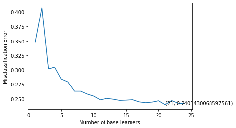

```
CPU times: user 130 ms, sys: 4.77 ms, total: 135 ms
Wall time: 133 ms
```

```python
%%time
# plotting the error as k increases
error = [1 - x for x in cv_scores]                                 #error corresponds to each nu of estimator
optimal_learners = base_ln[error.index(min(error))]                #Selection of optimal nu of n_estimator corresponds to minimum error.
plt.plot(base_ln, error)                                           #Plot between each nu of estimator and misclassification error
xy = (optimal_learners, min(error))
plt.annotate('(%s, %s)' % xy, xy = xy, textcoords='data')
plt.xlabel("Number of base learners")
plt.ylabel("Misclassification Error")
plt.show()
```

```python
# Training the best model and calculating accuracy on test data .
clf = RandomForestClassifier(n_estimators = optimal_learners)
clf.fit(X_train, y_train)
clf.score(X_test, y_test)
```

```
0.7734517304189436
```

```python
result =  clf.predict(X_test)
```

```
[[ 462   64  358]
 [  96  422  176]
 [ 238   63 2513]]
0.7734517304189436
```

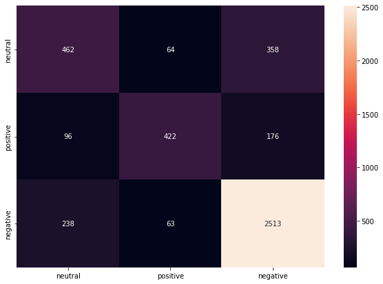

```python
# Print and plot Confusion matirx to get an idea of how the distribution of the prediction is, among all the classes.
conf_mat = confusion_matrix(y_test, result)

print(conf_mat)

print(metrics.f1_score(y_test, result,average='micro'))
sentiment = ['neutral', 'positive', 'negative']

df_cm = pd.DataFrame(conf_mat, index = [i for i in sentiment],
                  columns = [i for i in sentiment])
plt.figure(figsize = (10,7))
sns.heatmap(df_cm, annot=True, fmt='g')
```

### Word Cloud of top 20 important features from the CountVectorizer + Random Forest based model

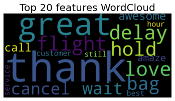

```python
all_features = bow_vec.get_feature_names()              #Instantiate the feature from the vectorizer
top_features=''                                            # Addition of top 20 feature into top_feature after training the model
feat=clf.feature_importances_
features=np.argsort(feat)[::-1]
for i in features[0:20]:
    top_features+=all_features[i]
    top_features+=' '



from wordcloud import WordCloud
wordcloud = WordCloud(background_color="black",colormap='viridis',width=2000,
                          height=1000).generate(top_features)

# Display the generated image:
plt.imshow(wordcloud, interpolation='bilinear')
plt.figure(1, figsize=(15, 15), frameon='equal')
plt.title('Top 20 features WordCloud', fontsize=20)
plt.axis("off")
plt.show()
```

- Accuracy of the model is around 77%.
- After fitting CountVectorizer with Random Forest out of top 20 features some positive comments like "Thank", "great", "love" stands out.
- We have also seen some negative words like "delay", "cancel", "wait" are displayed amongst top 20 words.

## Build the model based on Term Frequency(TF) - Inverse Document Frequency(IDF) and Random forest

```python
# Using TfidfVectorizer to convert text data to numbers.

vectorizer = TfidfVectorizer(max_features=8000)
data_features = vectorizer.fit_transform(sentiment_data['text'])

data_features = data_features.toarray()

data_features.shape
```

```
(14640, 8000)
```

```python
# Split data into training and testing set.

X_train, X_test, y_train, y_test = train_test_split(data_features, labels, test_size=0.3, random_state=42)
```

```python
# Using Random Forest to build model for the classification of reviews.
# Also calculating the cross validation score.

forest = RandomForestClassifier(n_estimators=10, n_jobs=4)

forest = forest.fit(X_train, y_train)

print(forest)

print(np.mean(cross_val_score(forest, data_features, labels, cv=5)))
```

```
RandomForestClassifier(n_estimators=10, n_jobs=4)
0.7465846994535519
```

```python
%%time
# K - Fold Cross Validation .
cv_scores = []
for b in base_ln:
    clf = RandomForestClassifier(n_estimators = b, n_jobs=4)
    scores = cross_val_score(clf, X_train, y_train, cv = 10, scoring = 'accuracy')
    cv_scores.append(scores.mean())
```

```
CPU times: user 2min, sys: 30.8 s, total: 2min 31s
Wall time: 17min 10s
```

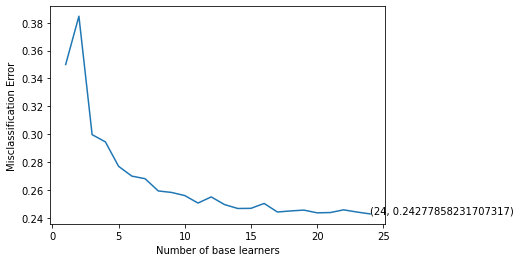

```
CPU times: user 129 ms, sys: 3.73 ms, total: 133 ms
Wall time: 131 ms
```

```python
%%time
# plotting the error as k increases
error = [1 - x for x in cv_scores]                                              #error corresponds to each nu of estimator
optimal_learners = base_ln[error.index(min(error))]                             #Selection of optimal nu of n_estimator corresponds to minimum error.
plt.plot(base_ln, error)                                                        #Plot between each nu of estimator and misclassification error
xy = (optimal_learners, min(error))
plt.annotate('(%s, %s)' % xy, xy = xy, textcoords='data')
plt.xlabel("Number of base learners")
plt.ylabel("Misclassification Error")
plt.show()
```

```python
# Training the best model and calculating error on test data .
clf = RandomForestClassifier(n_estimators = optimal_learners)
clf.fit(X_train, y_train)
clf.score(X_test, y_test)
```

```
0.7725409836065574
```

```python
result = clf.predict(X_test)
```

```python
# Display format of result variable
result
```

```
array([2, 3, 3, ..., 3, 3, 3])
```

```
[[ 437   61  386]
 [  89  392  213]
 [ 195   55 2564]]
0.7725409836065574
```

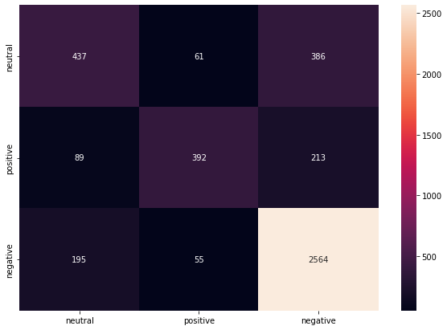

```python
# Print and plot Confusion matirx to get an idea of how the distribution of the prediction is, among all the classes.
conf_mat = confusion_matrix(y_test, result)

print(conf_mat)

print(metrics.f1_score(y_test, result,average='micro'))
sentiment = ['neutral', 'positive', 'negative']

df_cm = pd.DataFrame(conf_mat, index = [i for i in sentiment],
                  columns = [i for i in sentiment])
plt.figure(figsize = (10,7))
sns.heatmap(df_cm, annot=True, fmt='g')
```

### Word Cloud of top 20 important features from the Term Frequency(TF) - Inverse Document Frequency(IDF) and Random forest

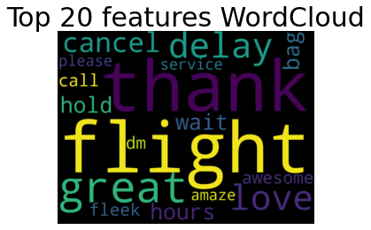

```python
all_features = vectorizer.get_feature_names()                                #Instantiate the feature from the vectorizer
Top_features=''                                                              #Addition of top 20 feature into top_feature after training the model
feat=clf.feature_importances_
features=np.argsort(feat)[::-1]
for i in features[0:20]:
    Top_features+=all_features[i]
    Top_features+=' '


from wordcloud import WordCloud
wordcloud = WordCloud(background_color="Black",width=1000,
                          height=750).generate(Top_features)

# Display the generated image:
plt.imshow(wordcloud, interpolation='bilinear')
plt.figure(1, figsize=(15, 15), frameon='equal')
plt.title('Top 20 features WordCloud', fontsize=30)
plt.axis("off")
plt.show()
```

## Build the model Artificial Neural Network with TF-IDF Vectorizer

```python
# Keras modules for data analysis
import tensorflow as tf
from tensorflow.keras.models import Sequential, Model #sequential api for sequential model
from tensorflow.keras.layers import Dense, Dropout, Flatten, Conv2D, MaxPooling2D, BatchNormalization, Activation, Input, Activation
from tensorflow.keras import backend
from tensorflow.keras.utils import to_categorical #to perform one-hot encoding
from tensorflow.keras.optimizers import RMSprop,Adam,SGD #optimiers for optimizing the model
from tensorflow.keras.callbacks import EarlyStopping  #regularization method to prevent the overfitting
from tensorflow.keras.callbacks import ModelCheckpoint
from tensorflow.keras import losses, optimizers
from sklearn.preprocessing import LabelBinarizer
```

```python
# Clearing the backend session and initializing the random seed values
import random
backend.clear_session()
np.random.seed(42)
random.seed(42)
tf.random.set_seed(42)
```

```python
# Get the labels
labels = sentiment_data['airline_sentiment']
labels[:5]
```

```
0     neutral
1    positive
2     neutral
3    negative
4    negative
Name: airline_sentiment, dtype: object
```

```python
# Splitting data
X_train, X_test, y_train, y_test = train_test_split(data_features,labels , test_size=0.3, random_state=42)
```

```python
# Encoding Target Variable
# We shall use LabelBinarizer
enc = LabelBinarizer()
y_train_encoded = enc.fit_transform(y_train)
y_test_encoded=enc.transform(y_test)
```

```python
# Print to validate the encoded data
print(y_train_encoded[:5])
print(y_test_encoded[0])
```

```
[[0 1 0]
 [1 0 0]
 [1 0 0]
 [0 0 1]
 [0 1 0]]
[0 0 1]
```

```python
# Print to identify the coding. This is going to be used for plotting confusion matrix
y_train[:5]

# We see that Negative = 0, Neutral = 1 and Positive = 2
```

```
7717      neutral
13854    negative
11719    negative
239      positive
8582      neutral
Name: airline_sentiment, dtype: object
```

```python
X_train.shape[1]
```

```
8000
```

```python
# Build Model

tf.random.set_seed(42)
model = Sequential()
model.add(Dense(256,activation='relu',input_dim = X_train.shape[1]))
model.add(Dense(128,activation='relu', kernel_initializer='he_uniform'))
model.add(Dense(64,activation='relu', kernel_initializer='he_uniform'))
model.add(Dense(32,activation='relu', kernel_initializer='he_uniform'))
model.add(Dense(3, activation = 'softmax'))
optimizer = tf.keras.optimizers.Adam(0.001)
model.compile(loss=losses.categorical_crossentropy, optimizer=optimizer, metrics=['accuracy'])
```

```python
# Fitting the model
history = model.fit(X_train,y_train_encoded,batch_size=64,epochs=50, verbose=1)
```

```python
# Evaluation on Test Data
accuracy = model.evaluate(X_test, y_test_encoded, verbose=2)
```

```
138/138 - 0s - loss: 2.0340 - accuracy: 0.7716 - 443ms/epoch - 3ms/step
```

```python
# Here we would get the output as probablities for each category
y_pred=model.predict(X_test)
```

```
[[2482  232  100]
 [ 346  460   78]
 [ 142  105  447]]
0.7716302367941712
```

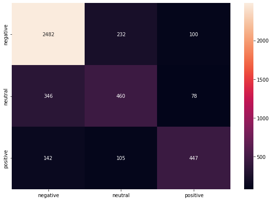

```python
# Print and plot Confusion matirx to get an idea of how the distribution of the prediction is, among all the classes.

y_pred_arg=np.argmax(y_pred,axis=1)
y_test_arg=np.argmax(y_test_encoded,axis=1)
conf_mat = confusion_matrix(y_test_arg, y_pred_arg)

print(conf_mat)

print(metrics.f1_score(y_test_arg, y_pred_arg,average='micro'))
sentiment = ['negative', 'neutral', 'positive']

df_cm = pd.DataFrame(conf_mat, index = [i for i in sentiment],
                  columns = [i for i in sentiment])
plt.figure(figsize = (10,7))
sns.heatmap(df_cm, annot=True, fmt='g')
```

```python
# Classification Report
cr=metrics.classification_report(y_test_arg,y_pred_arg)
print(cr)
```

```
              precision    recall  f1-score   support

           0       0.84      0.88      0.86      2814
           1       0.58      0.52      0.55       884
           2       0.72      0.64      0.68       694

    accuracy                           0.77      4392
   macro avg       0.71      0.68      0.69      4392
weighted avg       0.76      0.77      0.77      4392
```

# Summarization

```python
# Let's summarize various test accuracy measures accross all models in a tabular form
import pandas as pd
df_perf = pd.DataFrame(
    {
        "Model": ['CountVect_RandForest', 'TFIDFVect_RandForest', 'ANN'],
        "Test Accuracy": [77.34, 77.25, 77.16]
    }
)
df_perf
```

|  | Model | Test Accuracy |
| --- | --- | --- |
| 0 | CountVect_RandForest | 77.34 |
| 1 | TFIDFVect_RandForest | 77.25 |
| 2 | ANN | 77.16 |

# Actionable Insights and Recommendations

**General Comments on Model Improvement**

- From the summary, we see that all the three models have performed consistently at 77%. Count Vectorizer with Random forest has perfomed the best.
- In the ANN model, we have used TF-IDF vectorizer.
- There is a possibility to improve the ANN model even further, by applying more epochs or adding some normalization technique (Batch Normalization or Dropout layer).
- We may also chose to improve on the Count Vectorizer with Random forest by tuning more hyper parameters like max_features or ngram_range.
- There are some negative comments which makes more sense when apply bi-gram or tri-gram, like "Customer Service Issue", "Lost Baggage", Late Flight, Delayed Flight and so on.
- Overall, all the three models have performed pretty nice on Negative sentiment.

**Business Recommendation**

- Approximately 63% of the dataset had negative sentiments.
- During the analysis we found Customer Service is a major issue category on negative sentiments. Airline must look at that area little closer.
- Late Flight, Delayed Flight are other two issues that are displayed prominently on negative sentiment analysis.
- Around 16% of the data in had positive sentiments.
- There are certain words stands out in our analysis on positive sentiments, like "Love", "Awesome" and so on. The airlines must make efforts to have more such sentiments.